# Social Care Survey Open Data

Import and Tidy - dataMaid example

# 1 Introduction

The social care survey is collected anually by the Scottish Government from all of the 32 Local Authorities in Scotland. Full history of data collection and metadata for the public release files in available [here](http://www.gov.scot/Resource/0040/00409164.pdf).

Public release data is for 3 years - 2010, 2011, and 2012 and is avaiable [here](http://www.gov.scot/Topics/Statistics/Browse/Health/Data/HomeCare/HSC-Datasets-HCPRF).

## 1.1 Aims

- Import data into R
- Tidy and coerce variables
- Save data as .rds objects

## 1.2 Packages

Load required packages

```r
library(readr)
library(dplyr)
library(forcats)
```

# 2 Import Data

I’ve downloaded these files into the “raw_data” project folder and I’ll imort them into R now,

```r
soc_care10 <- read_csv("raw_data/public_release_sc_2010.csv")
soc_care11 <- read_csv("raw_data/public_release_sc_2011.csv")
soc_care12 <- read_csv("raw_data/public_release_sc_2012.csv")
```

# 3 Tidy data

Let’s start by looking at each set of data

## 3.1 Glimpse

```r
glimpse(soc_care10)
```

```
## Observations: 76,202
## Variables: 19
## $ LAcode            <int> 100, 100, 100, 100, 100, 100, 100, 100, 100,...
## $ clientID          <chr> "ZZXJX", "VLKT8", "418H1", "7SF1N", "TKCFN",...
## $ AgeGRP            <int> 5, 4, 3, 4, 3, 3, 3, 3, 3, 5, 1, 4, 3, 4, 3,...
## $ ClientGRP         <chr> ".", "4", "4", "4", "4", "4", "4", "4", "4",...
## $ GenderISO         <chr> ".", "1", "1", "1", "1", "2", "1", "1", "1",...
## $ meals             <int> 1, 1, 0, 0, 0, 1, 0, 0, 0, 1, 0, 1, 0, 0, 0,...
## $ bandHRSLA         <int> 0, 0, 0, 0, 0, 0, 0, 0, 5, 0, 0, 0, 2, 7, 0,...
## $ bandHRSpri        <int> 0, 3, 5, 5, 8, 8, 3, 4, 0, 0, 3, 7, 0, 7, 5,...
## $ bandHRSvol        <int> 0, 0, 0, 0, 0, 0, 0, 0, 0, 0, 0, 0, 0, 0, 0,...
## $ bandHRSPC         <int> 0, 0, 0, 0, 0, 0, 0, 0, 0, 0, 0, 0, 0, 0, 0,...
## $ bandHRSTT         <int> 0, 3, 5, 5, 8, 8, 3, 4, 5, 0, 3, 7, 2, 9, 5,...
## $ HCclient          <int> 0, 1, 1, 1, 1, 1, 1, 1, 1, 0, 1, 1, 1, 1, 1,...
## $ LivingArr         <int> 0, 9, 2, 1, 1, 1, 9, 9, 2, 0, 2, 1, 1, 2, 2,...
## $ Staff             <int> 0, 0, 0, 0, 0, 0, 0, 0, 0, 0, 1, 0, 0, 0, 0,...
## $ HousingType_OV    <int> 0, 0, 0, 0, 0, 0, 0, 0, 0, 0, 0, 0, 0, 0, 0,...
## $ Laundry_OV        <int> 0, 0, 0, 0, 0, 0, 0, 0, 0, 0, 0, 0, 0, 0, 0,...
## $ Shopping_OV       <int> 0, 0, 0, 0, 0, 0, 0, 0, 0, 0, 0, 0, 0, 0, 0,...
## $ HousingSupport_OV <int> 0, 0, 0, 0, 0, 0, 0, 0, 0, 0, 0, 0, 0, 0, 0,...
## $ IoRN_OV           <chr> NA, NA, NA, NA, NA, NA, NA, NA, NA, NA, NA, ...
```

```r
glimpse(soc_care11)
```

```
## Observations: 142,466
## Variables: 22
## $ LAcode               <int> 100, 100, 100, 100, 100, 100, 100, 100, 1...
## $ clientID             <chr> "17L9J", "3Z8FK", "BKKAY", "8BT1I", "XMH3...
## $ AgeGRP               <int> 3, 4, 3, 3, 3, 4, 4, 3, 3, 4, 2, 3, 3, 3,...
## $ ClientGRP            <int> 4, 4, 1, 1, 4, 4, 4, 4, 4, 4, 1, 4, 4, 4,...
## $ GenderISO            <int> 2, 2, 2, 2, 1, 1, 2, 1, 2, 2, 2, 1, 2, 2,...
## $ meals                <int> NA, NA, NA, 1, NA, NA, NA, NA, NA, NA, NA...
## $ bandHRSLA            <int> 0, 0, 0, 0, 0, 0, 0, 0, 8, 1, 0, 0, 0, 0,...
## $ bandHRSpri           <int> 0, 0, 0, 0, 2, 5, 4, 8, 0, 0, 0, 0, 3, 5,...
## $ bandHRSvol           <int> 0, 0, 0, 0, 0, 0, 0, 0, 0, 0, 0, 0, 0, 0,...
## $ bandHRSPC            <int> 0, 0, 0, 0, 2, 5, 4, 8, 8, 1, 0, 0, 3, 5,...
## $ bandHRSTT            <int> 0, 0, 0, 0, 2, 5, 4, 8, 8, 1, 0, 0, 3, 5,...
## $ HCclient             <int> 0, 0, 0, 0, 1, 1, 1, 1, 1, 1, 0, 0, 1, 1,...
## $ communityalarmonly   <int> 0, 1, 1, 0, 0, 0, 1, 1, 0, 0, 0, 1, 1, 0,...
## $ telecareonly         <int> 1, 0, 0, 0, 0, 0, 0, 0, 0, 0, 1, 0, 0, 0,...
## $ communityandtelecare <int> 0, 0, 0, 0, 0, 0, 0, 0, 0, 0, 0, 0, 0, 0,...
## $ LivingArr            <int> 9, 2, 9, 9, 9, 1, 1, 1, 9, 9, 2, 9, 1, 2,...
## $ Staff                <int> 0, 0, 0, 0, 0, 0, 0, 0, 1, 0, 0, 0, 0, 1,...
## $ HousingType_OV       <int> 0, 0, 0, 0, 0, 0, 0, 0, 0, 0, 0, 0, 0, 0,...
## $ Laundry_OV           <int> 0, 0, 0, 0, 0, 0, 0, 0, 0, 0, 0, 0, 0, 0,...
## $ Shopping_OV          <int> 0, 0, 0, 0, 0, 0, 0, 0, 0, 0, 0, 0, 0, 0,...
## $ HousingSupport_OV    <int> 0, 0, 0, 0, 0, 0, 0, 0, 0, 0, 0, 0, 0, 0,...
## $ IoRN_OV              <chr> NA, NA, NA, NA, NA, NA, NA, NA, NA, NA, N...
```

```r
glimpse(soc_care12)
```

```
## Observations: 141,144
## Variables: 26
## $ LAcode               <int> 100, 100, 100, 100, 100, 100, 100, 100, 1...
## $ clientID             <chr> "HRXYJ", "U61VU", "XP2LW", "3VXIH", "4CC3...
## $ AgeGRP               <int> 3, 4, 3, 3, 4, 3, 4, 2, 3, 4, 3, 1, 3, 4,...
## $ ClientGRP            <int> 4, 4, 1, 4, 4, 4, 4, 1, 4, 4, 4, 1, 4, 4,...
## $ GenderISO            <int> 2, 2, 2, 1, 1, 2, 2, 2, 1, 2, 2, 1, 1, 2,...
## $ meals                <int> NA, NA, 1, NA, NA, NA, NA, NA, NA, NA, NA...
## $ error1               <chr> NA, NA, NA, NA, NA, NA, NA, NA, NA, NA, N...
## $ error                <chr> NA, NA, NA, NA, NA, NA, NA, NA, NA, NA, N...
## $ newhours             <int> NA, 2, NA, 3, 7, 18, 1, NA, NA, 3, 7, NA,...
## $ HCFlag               <int> 0, 1, 0, 1, 1, 1, 1, 0, 0, 1, 1, 0, 1, 0,...
## $ bandHRSLA            <int> 0, 0, 0, 0, 0, 8, 1, 0, 0, 0, 5, 0, 0, 0,...
## $ bandHRSpri           <int> 0, 3, 0, 3, 5, 0, 0, 0, 0, 3, 0, 0, 6, 0,...
## $ bandHRSvol           <int> 0, 0, 0, 0, 0, 0, 0, 0, 0, 0, 0, 0, 0, 0,...
## $ bandHRSPC            <int> 0, 3, 0, 3, 5, 8, 1, 0, 0, 3, 5, 0, 6, 0,...
## $ bandHRSTT            <int> 0, 3, 0, 3, 5, 8, 1, 0, 0, 3, 5, 0, 6, 0,...
## $ HCclient             <int> 0, 1, 0, 1, 1, 1, 1, 0, 0, 1, 1, 0, 1, 0,...
## $ communityalarmonly   <int> 0, 1, 0, 0, 0, 0, 0, 0, 1, 1, 0, 1, 1, 1,...
## $ telecareonly         <int> 1, 0, 0, 0, 0, 0, 0, 1, 0, 0, 0, 0, 0, 0,...
## $ communityandtelecare <int> 0, 0, 0, 0, 0, 0, 0, 0, 0, 0, 0, 0, 0, 0,...
## $ LivingArr            <int> 9, 2, 9, 9, 1, 9, 9, 2, 9, 1, 1, 9, 1, 9,...
## $ Staff                <int> 0, 0, 0, 0, 0, 1, 0, 0, 0, 0, 0, 0, 0, 0,...
## $ HousingType_OV       <int> 0, 0, 0, 0, 0, 0, 0, 0, 0, 0, 0, 0, 0, 0,...
## $ Laundry_OV           <int> 0, 0, 0, 0, 0, 0, 0, 0, 0, 0, 0, 0, 0, 0,...
## $ Shopping_OV          <int> 0, 0, 0, 0, 0, 0, 0, 0, 0, 0, 0, 0, 0, 0,...
## $ HousingSupport_OV    <int> 0, 0, 0, 0, 0, 0, 0, 0, 0, 0, 0, 0, 0, 0,...
## $ IoRN_OV              <chr> NA, NA, NA, NA, NA, NA, NA, NA, NA, NA, N...
```

The reason for the discrepancies in observations is that 2011 and 2012 data contains information on individuals who received not just home care, but also telecare which almost doubles the number of people included.

3 telecare variables are added in 2011. In 2012 these 3 variables are present plus an extra variable `newhours`. There are also 3 unneeded variables in 2012; `error`, `error1`, and `HCFlag`. The first two are self-explanatory. The third is a duplicate of the `HCclient` variable. I’ll drop these now before we start to tidy.

```r
soc_care12 %>% select(-error, -error1, -HCFlag) -> soc_care12
```

With the exception of`clientID` in each year, every variable needs coerced. The majority of these variables should be factors. I could re-import the data and try `stringsasFactor == TRUE`. I’m not so sure this would work and, anyhow, I want to explicitly name the labels for the factors.

1st of all though, we’ll sort out the variable names.

# 4 New names

```r
#different number of coulmns in each year so requires seperate commands

names(soc_care10) <- c("council", "client_id", "age_grp", "client_grp", "gender", "meals",
                       "la_hrs", "pri_hrs", "vol_hrs", "pc_hrs", "total_hrs", "hc_client",
                       "living_arr", "multi_staff", "housing_type", "laundry", "shopping",
                       "housing_supp", "iorn_score")

names(soc_care11) <- c("council", "client_id", "age_grp", "client_grp", "gender", "meals",
                       "la_hrs", "pri_hrs", "vol_hrs", "pc_hrs", "total_hrs", "hc_client",
                       "comm_alarm", "other_telecare", "alarm_and_tele", "living_arr",
                       "multi_staff", "housing_type", "laundry", "shopping",
                       "housing_supp", "iorn_score")

names(soc_care12) <- c("council", "client_id", "age_grp", "client_grp", "gender", "meals",
                       "new_hrs", "la_hrs", "pri_hrs", "vol_hrs", "pc_hrs", "total_hrs",
                       "hc_client", "comm_alarm", "other_telecare", "alarm_and_tele",
                       "living_arr", "multi_staff", "housing_type", "laundry", "shopping",
                       "housing_supp", "iorn_score")
```

I’ll coerce each in order here. I’m being explicit so I can set the labels for each factor level. All labels and levels identified from the [metadata file](http://www.gov.scot/Resource/0040/00409164.pdf).

## 4.1 Local Authority Code

```r
la_levels <- c("100", "110", "120", "130", "150", "170","180","190","200", "210", "220",
              "230", "235", "240", "250", "260","270", "280", "290", "300", "310", "320",
              "330", "340","350", "355", "360", "370", "380", "390", "395", "400")
la_labels <- c("Aberdeen City", "Aberdeenshire", "Angus", "Argyll & Bute", "Clackmannanshire",
              "Dumfries & Galloway", "Dundee City", "East Ayrshire",
              "East Dunbartonshire","East Lothian", "East Renfrewshire",
              "Edinburgh, City of", "Eilean Siar", "Falkirk", "Fife", "Glasgow City",
              "Highland","Inverclyde", "Midlothian", "Moray", "North Ayrshire",
              "North Lanarkshire", "Orkney Islands","Perth & Kinross", "Renfrewshire",
              "Scottish Borders", "Shetland Islands","South Ayrshire", "South Lanarkshire",
              "Stirling","West Dunbartonshire","West Lothian")

soc_care10$council <- factor(soc_care10$council,
                            levels = la_levels,
                            labels = la_labels)

soc_care11$council <- factor(soc_care11$council,
                            levels = la_levels,
                            labels = la_labels)

soc_care12$council <- factor(soc_care12$council,
                            levels = la_levels,
                            labels = la_labels)

rm(list = c("la_labels", "la_levels"))
```

## 4.2 Age Group

`age_grp` has been imported as an integer - factorise.

```r
age_grp_levels = c("1", "2", "3", "4", "5")
age_grp_labels <- c("18-<65", "65-<75", "75-<85", "85+", "Unknown")

#2010

soc_care10$age_grp <- factor(soc_care10$age_grp,
                            levels = age_grp_levels,
                            labels = age_grp_labels)
soc_care10$age_grp[soc_care10$age_grp == "Unknown"] <- NA #Convert Missing data to NA
soc_care10$age_grp <- fct_drop(soc_care10$age_grp, only = "Unknown") #Drop unknown level


#2011

soc_care11$age_grp <- factor(soc_care11$age_grp,
                            levels = age_grp_levels,
                            labels = age_grp_labels)
soc_care11$age_grp[soc_care11$age_grp == "Unknown"] <- NA #Convert missing data to NA
soc_care11$age_grp <- fct_drop(soc_care11$age_grp, only = "Unknown")

#2012

soc_care12$age_grp <- factor(soc_care12$age_grp,
                            levels = age_grp_levels,
                            labels = age_grp_labels)
soc_care12$age_grp[soc_care12$age_grp == "Unknown"] <- NA #Convert Missing data to NA
soc_care12$age_grp <- fct_drop(soc_care12$age_grp, only = "Unknown")

rm(list = c("age_grp_labels", "age_grp_levels"))
```

## 4.3 Client Group

```r
client_grp_levels <- c("1", "2", "3", "4", "5", "99", ".")
client_grp_labels <- c("Dementia & Mental Health", "Learning Disability",
                     "Physical Disability", "Infirmity due to Age","Other",
                     "Not Known", "Blank")

#2010

soc_care10$client_grp <- factor(soc_care10$client_grp,
                               levels = client_grp_levels,
                               labels = client_grp_labels)

soc_care10$client_grp <- fct_collapse(soc_care10$client_grp,
                                      missing = c("Not Known", "Blank"))

soc_care10$client_grp[soc_care10$client_grp == "missing"] <- NA #Covert missing data to NA
soc_care10$client_grp <- fct_drop(soc_care10$client_grp, only = "missing") #drop missing level


#2011

soc_care11$client_grp <- factor(soc_care11$client_grp,
                               levels = client_grp_levels,
                               labels = client_grp_labels)

soc_care11$client_grp <- fct_collapse(soc_care11$client_grp,
                                      missing = c("Not Known", "Blank"))

soc_care11$client_grp[soc_care11$client_grp == "missing"] <- NA #Covert missing data to NA
soc_care11$client_grp <- fct_drop(soc_care11$client_grp, only = "missing") #drop missing level


#2012
soc_care12$client_grp <- factor(soc_care12$client_grp,
                               levels = client_grp_levels,
                               labels = client_grp_labels)
soc_care12$client_grp <- fct_collapse(soc_care12$client_grp,
                                      missing = c("Not Known", "Blank"))

soc_care12$client_grp[soc_care12$client_grp == "missing"] <- NA #Covert missing data to NA
soc_care12$client_grp <- fct_drop(soc_care12$client_grp, only = "missing") #drop missing level

rm(list = c("client_grp_labels", "client_grp_levels"))
```

## 4.4 Gender

```r
#2010
soc_care10$gender <- factor(soc_care10$gender,
                               levels = c("1", "2", "."),
                               labels = c("Male", "Female", "Blank"))
soc_care10$gender[soc_care10$gender == "Blank"] <- NA #Convert missing to NA level
soc_care10$gender <- fct_drop(soc_care10$gender, only = "Blank") #and drop empty level

#2011
soc_care11$gender <- factor(soc_care11$gender,
                               levels = c("1", "2", "."),
                               labels = c("Male", "Female", "Blank"))
soc_care11$gender[soc_care11$gender == "Blank"] <- NA #Convert missing to NA level
soc_care11$gender <- fct_drop(soc_care11$gender, only = "Blank") #and drop empty level

#2012
soc_care12$gender <- factor(soc_care12$gender,
                               levels = c("1", "2", "."),
                               labels = c("Male", "Female", "Blank"))
soc_care12$gender[soc_care12$gender == "Blank"] <- NA #Convert missing to NA level
soc_care12$gender <- fct_drop(soc_care12$gender, only = "Blank") #and drop empty level
```

## 4.5 Meals

Factorise meals - dichotomous variable. **The 2011 and 2012 .csv files only seem to have values for meals meaning we have to presume empty values are “no meals”, rather than missing data.** Not too sure about this but will investgate further in the analysis. For now the data stays as missing and will be computed as NA

```r
soc_care10$meals <- factor(soc_care10$meals,
                           levels = c("0", "1"),
                           labels = c("No meals", "Meals"))


soc_care11$meals <- factor(soc_care11$meals,
                           levels = c("0", "1"),
                           labels = c("No meals", "Meals"))


soc_care12$meals <- factor(soc_care12$meals,
                           levels = c("0", "1"),
                           labels = c("No meals", "Meals"))
```

## 4.6 Home Care Hours

Need to factorise Home Care Hours also. This variable has been pre-banded but imported as an integer. Start with the Total Hours

```r
hrs_levels <- c("0", "1", "2", "3", "4", "5", "6", "7", "8", "9", "10", "11", "12")
hrs_labels <- c("Zero", "<1", "1-2", "2-4", "4-6","6-8", "8-10", "10-15", "15-20",
                    "20-30","30-40", "40-50", "over50")

soc_care10$total_hrs <- factor(soc_care10$total_hrs,
                               levels = hrs_levels,
                               labels = hrs_labels)

soc_care11$total_hrs <- factor(soc_care11$total_hrs,
                               levels = hrs_levels,
                               labels = hrs_labels)

soc_care12$total_hrs <- factor(soc_care12$total_hrs,
                               levels = hrs_levels,
                               labels = hrs_labels)
```

Now need to do all the other Home Care Hours variables.

```r
#2010
soc_care10$la_hrs <- factor(soc_care10$la_hrs,
                               levels = hrs_levels,
                               labels = hrs_labels)

soc_care10$pri_hrs <- factor(soc_care10$pri_hrs,
                               levels = hrs_levels,
                               labels = hrs_labels)

soc_care10$vol_hrs <- factor(soc_care10$vol_hrs,
                               levels = hrs_levels,
                               labels = hrs_labels)

soc_care10$pc_hrs <- factor(soc_care10$pc_hrs,
                               levels = hrs_levels,
                               labels = hrs_labels)
#2011
soc_care11$la_hrs <- factor(soc_care11$la_hrs,
                               levels = hrs_levels,
                               labels = hrs_labels)

soc_care11$pri_hrs <- factor(soc_care11$pri_hrs,
                               levels = hrs_levels,
                               labels = hrs_labels)

soc_care11$vol_hrs <- factor(soc_care11$vol_hrs,
                               levels = hrs_levels,
                               labels = hrs_labels)

soc_care11$pc_hrs <- factor(soc_care11$pc_hrs,
                               levels = hrs_levels,
                               labels = hrs_labels)
#2012
soc_care12$la_hrs <- factor(soc_care12$la_hrs,
                               levels = hrs_levels,
                               labels = hrs_labels)

soc_care12$pri_hrs <- factor(soc_care12$pri_hrs,
                               levels = hrs_levels,
                               labels = hrs_labels)

soc_care12$vol_hrs <- factor(soc_care12$vol_hrs,
                               levels = hrs_levels,
                               labels = hrs_labels)

soc_care12$pc_hrs <- factor(soc_care12$pc_hrs,
                               levels = hrs_levels,
                               labels = hrs_labels)

rm(list = c("hrs_labels", "hrs_levels"))
```

There are no Personal Care hours data for 2010 - Let’s drop that now.

```r
soc_care10 %>%
  select(-pc_hrs) -> soc_care10
```

## 4.7 Home Care Client Flag

Factoris `hc_client` This is a derived variable indicating whether client recieved home care or not. Useful for subsetting.

```r
soc_care10$hc_client <- factor(soc_care10$hc_client,
                              levels = c("0", "1"),
                              labels = c("No", "Yes"))

soc_care11$hc_client <- factor(soc_care11$hc_client,
                              levels = c("0", "1"),
                              labels = c("No", "Yes"))

soc_care12$hc_client <- factor(soc_care12$hc_client,
                              levels = c("0", "1"),
                              labels = c("No", "Yes"))
```

## 4.8 Community alarm and Telecare

2011 and 2012 data have extra variables on community alarms and telecare. Again these are dichotomous variables and need factorised.

```r
#2011
soc_care11$other_telecare <- factor(soc_care11$other_telecare,
                                  levels = c("0", "1"),
                                  labels = c("No", "Yes"))
soc_care11$comm_alarm <- factor(soc_care11$comm_alarm,
                                        levels = c("0", "1"),
                                        labels = c("No", "Yes"))
soc_care11$alarm_and_tele <- factor(soc_care11$alarm_and_tele,
                                          levels = c("0", "1"),
                                          labels = c("No", "Yes"))

#2012
soc_care12$other_telecare <- factor(soc_care12$other_telecare,
                                  levels = c("0", "1"),
                                  labels = c("No", "Yes"))
soc_care12$comm_alarm <- factor(soc_care12$comm_alarm,
                                        levels = c("0", "1"),
                                        labels = c("No", "Yes"))
soc_care12$alarm_and_tele <- factor(soc_care12$alarm_and_tele,
                                          levels = c("0", "1"),
                                          labels = c("No", "Yes"))
```

## 4.9 Living Arrangements

All 3 years of data have Living Arrangement data signifying whether the client lives alone or not - factorise.

The metadata reports the level “9” as “Not known”. I think this counts as missing data so will code as NA.

```r
#2010
soc_care10$living_arr <- factor(soc_care10$living_arr,
                               levels = c("1", "2", "9"),
                               labels = c("Lives Alone", "Other", "Not Known"))
soc_care10$living_arr[soc_care10$living_arr == "Not Known"] <- NA
soc_care10$living_arr <- fct_drop(soc_care10$living_arr, only = "Not Known")

#2011
soc_care11$living_arr <- factor(soc_care11$living_arr,
                               levels = c("1", "2", "9"),
                               labels = c("Lives Alone", "Other", "Not Known"))
soc_care11$living_arr[soc_care11$living_arr == "Not Known"] <- NA
soc_care11$living_arr <- fct_drop(soc_care11$living_arr, only = "Not Known")

#2012
soc_care12$living_arr <- factor(soc_care12$living_arr,
                               levels = c("1", "2", "9"),
                               labels = c("Lives Alone", "Other", "Not Known"))
soc_care12$living_arr[soc_care12$living_arr == "Not Known"] <- NA
soc_care12$living_arr <- fct_drop(soc_care12$living_arr, only = "Not Known")
```

## 4.10 Multi Staffing

The Staff variable indicates whether multiple staff required or not. Dichotomous. Factorise.

```r
soc_care10$multi_staff <- factor(soc_care10$multi_staff,
                           levels = c("0", "1"),
                           labels = c("Single Staff", "2 or more Staff"))

soc_care11$multi_staff <- factor(soc_care11$multi_staff,
                           levels = c("0", "1"),
                           labels = c("Single Staff", "2 or more Staff"))

soc_care12$multi_staff <- factor(soc_care12$multi_staff,
                           levels = c("0", "1"),
                           labels = c("Single Staff", "2 or more Staff"))
```

## 4.11 Housing Type

`housing_type` is an optional variable from 2010. Interesting that there is not a code for missing or not known. We’ll see completeness when visualising…..

```r
soc_care10$housing_type <- factor(soc_care10$housing_type,
                                    levels = c("0", "1", "9"),
                                    labels = c("Mainstream", "Supported Housing",
                                               "Other"))

soc_care11$housing_type <- factor(soc_care11$housing_type,
                                    levels = c("0", "1", "9"),
                                    labels = c("Mainstream", "Supported Housing",
                                               "Other"))

soc_care12$housing_type <- factor(soc_care12$housing_type,
                                    levels = c("0", "1", "9"),
                                    labels = c("Mainstream", "Supported Housing",
                                               "Other"))
```

We have got NA values though! Good!

## 4.12 Laundry

`laundry` as above

```r
soc_care10$laundry <- factor(soc_care10$laundry,
                                levels = c("0", "1"),
                                labels = c("No", "Yes"))

soc_care11$laundry <- factor(soc_care11$laundry,
                                levels = c("0", "1"),
                                labels = c("No", "Yes"))

soc_care12$laundry <- factor(soc_care12$laundry,
                                levels = c("0", "1"),
                                labels = c("No", "Yes"))
```

## 4.13 Shopping

`shopping` As above

```r
soc_care10$shopping <- factor(soc_care10$shopping,
                                 levels = c("0", "1"),
                                 labels = c("No", "Yes"))

soc_care11$shopping <- factor(soc_care11$shopping,
                                 levels = c("0", "1"),
                                 labels = c("No", "Yes"))

soc_care12$shopping <- factor(soc_care12$shopping,
                                 levels = c("0", "1"),
                                 labels = c("No", "Yes"))
```

## 4.14 Housing Support

`housing_supp` As Above

```r
soc_care10$housing_supp <- factor(soc_care10$housing_supp,
                                       levels = c("0", "1"),
                                       labels = c("No", "Yes"))

soc_care11$housing_supp <- factor(soc_care11$housing_supp,
                                       levels = c("0", "1"),
                                       labels = c("No", "Yes"))

soc_care12$housing_supp <- factor(soc_care12$housing_supp,
                                       levels = c("0", "1"),
                                       labels = c("No", "Yes"))
```

## 4.15 IoRN

`iorn_score` As Above

```r
soc_care10$iorn_score <- factor(soc_care10$iorn_score,
                             levels = c("A", "B", "C", "D", "E", "F", "G", "H", "I"),
                             labels = c("Low", "LowB", "Medium", "LowD", "MediumE",
                                        "High", "MediumG", "HighH", "HighI"))

soc_care11$iorn_score <- factor(soc_care11$iorn_score,
                             levels = c("A", "B", "C", "D", "E", "F", "G", "H", "I"),
                             labels = c("Low", "LowB", "Medium", "LowD", "MediumE",
                                        "High", "MediumG", "HighH", "HighI"))

soc_care12$iorn_score <- factor(soc_care12$iorn_score,
                             levels = c("A", "B", "C", "D", "E", "F", "G", "H", "I"),
                             labels = c("Low", "LowB", "Medium", "LowD", "MediumE",
                                        "High", "MediumG", "HighH", "HighI"))
```

One last adjustment to make - 2012 data has a variable `new_hrs` which (correctly) has been left as an integer. However if an individual has no new home care hours a `NA` value is recorded. This will give us issues when imputing data. I’ll convert this variable to numeric and then assign `NA` values to `0`.

```r
soc_care12$new_hrs <- as.double(soc_care12$new_hrs)
soc_care12$new_hrs[is.na(soc_care12$new_hrs)] <- 0
glimpse(soc_care12$new_hrs)
```

```
##  num [1:141144] 0 2 0 3 7 18 1 0 0 3 ...
```

# 5 dataMaid diagnostics

```r
library(dataMaid)
clean(soc_care10, useVar = c("council", "age_grp", "client_grp", "gender",
                             "meals", "la_hrs", "pri_hrs", "vol_hrs",
                             "total_hrs", "hc_client", "living_arr",
                             "multi_staff", "housing_type", "laundry",
                             "shopping", "housing_supp", "iorn_score"),
      replace = TRUE)
```

```r
library(dataMaid)
```

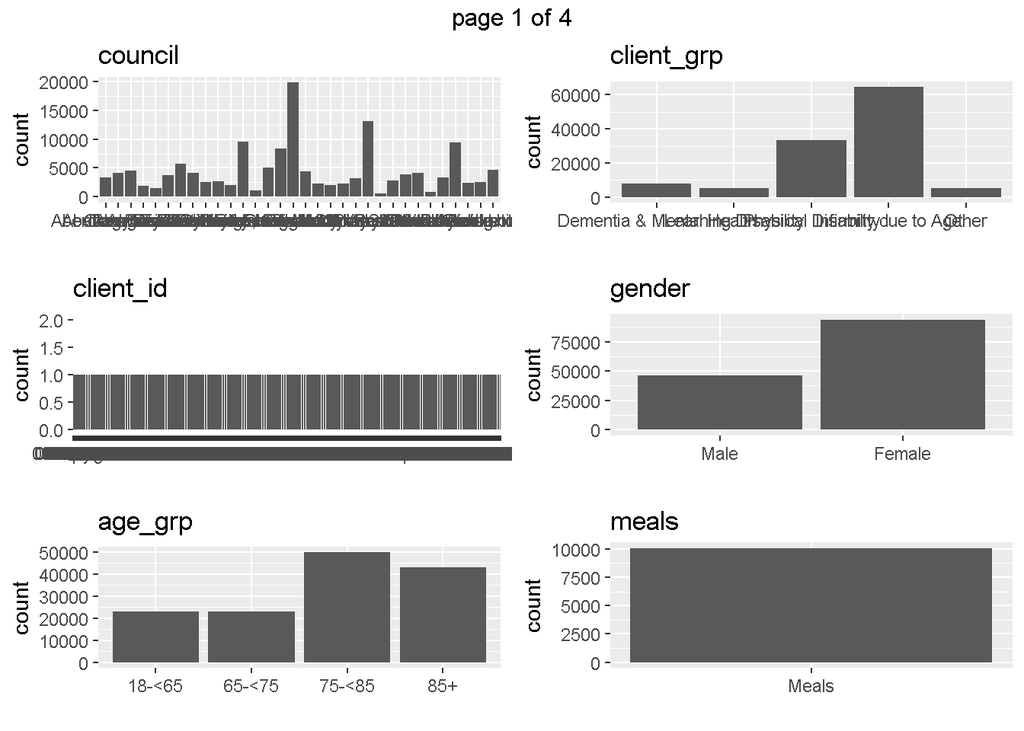

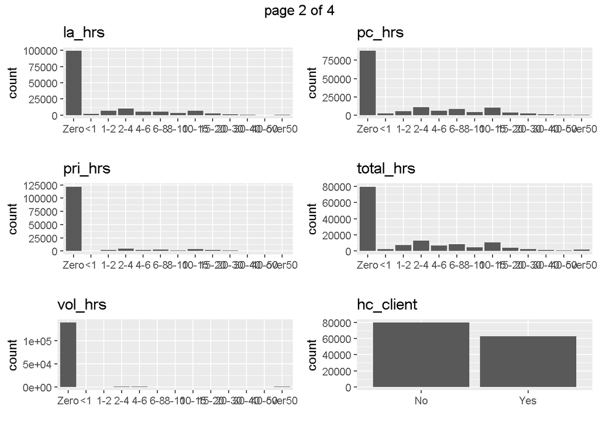

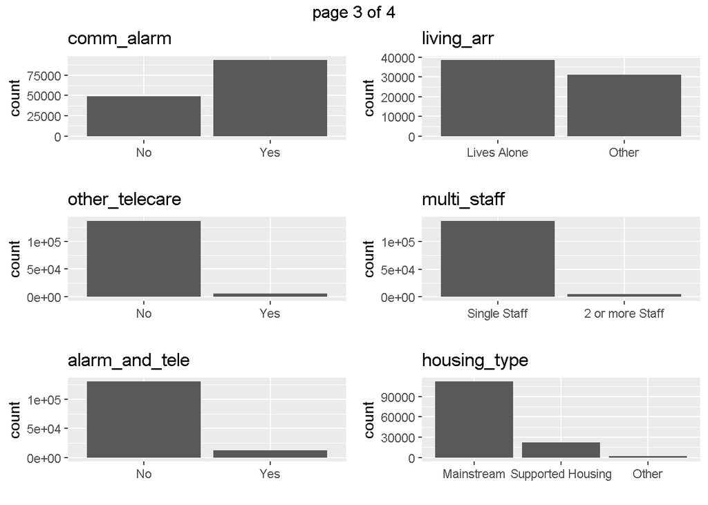

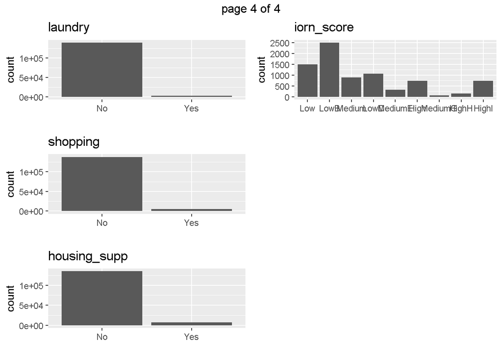

```r
visualize(soc_care11)
```

# 6 desctable

Quick try of this package

```r
library(desctable)


soc_care10 %>%
  desctable %>%
  kable
```

| council | 76202 | NA |
| --- | --- | --- |
| council: Aberdeen City | 2087 | 2.7387733 |
| council: Aberdeenshire | 4284 | 5.6218997 |
| council: Angus | 2843 | 3.7308732 |
| council: Argyll & Bute | 920 | 1.2073174 |
| council: Clackmannanshire | 2395 | 3.1429621 |
| council: Dumfries & Galloway | 2513 | 3.2978137 |
| council: Dundee City | 2479 | 3.2531955 |
| council: East Ayrshire | 1904 | 2.4986221 |
| council: East Dunbartonshire | 1452 | 1.9054618 |
| council: East Lothian | 1790 | 2.3490197 |
| council: East Renfrewshire | 917 | 1.2033805 |
| council: Edinburgh, City of | 4600 | 6.0365870 |
| council: Eilean Siar | 557 | 0.7309519 |
| council: Falkirk | 2700 | 3.5432141 |
| council: Fife | 5171 | 6.7859111 |
| council: Glasgow City | 7869 | 10.3265006 |
| council: Highland | 2041 | 2.6784074 |
| council: Inverclyde | 1547 | 2.0301304 |
| council: Midlothian | 1029 | 1.3503583 |
| council: Moray | 1423 | 1.8674051 |
| council: North Ayrshire | 1565 | 2.0537519 |
| council: North Lanarkshire | 3686 | 4.8371434 |
| council: Orkney Islands | 290 | 0.3805674 |
| council: Perth & Kinross | 2878 | 3.7768038 |
| council: Renfrewshire | 2197 | 2.8831264 |
| council: Scottish Borders | 1383 | 1.8149130 |
| council: Shetland Islands | 541 | 0.7099551 |
| council: South Ayrshire | 3032 | 3.9788982 |
| council: South Lanarkshire | 4021 | 5.2767644 |
| council: Stirling | 2465 | 3.2348232 |

[output cut: 108 more lines]

Awesome!

Lets’s save these tidied datasets for future reference

```r
#chunk not run!! Seperate example from original

save(soc_care10, file = "produced_data/created_objects/soc_care10.rds")
save(soc_care11, file = "produced_data/created_objects/soc_care11.rds")
save(soc_care12, file = "produced_data/created_objects/soc_care12.rds")
```

# 7 Summary

There may need to be other variables dropped but I will check how random data is missing in the next analysis.

```
##  setting  value
##  version  R version 3.4.1 (2017-06-30)
##  system   x86_64, mingw32
##  ui       RStudio (1.1.372)
##  language (EN)
##  collate  English_United Kingdom.1252
##  tz       Europe/London
##  date     2017-10-05
```

```
## Packages -----------------------------------------------------------------
```

[output not shown]

[output cut: 57 more lines]

[output not shown]